# A Databservatory for Human Behavior

2017-02-22 10:52:00

**"A Databservatory for Human Behavior"**

### **Rick O. Gilmore**

*Support*: NSF BCS-1147440, NSF BCS-1238599, NICHD U01-HD-076595

[figure not shown]

## Prelude

## Psychology is harder than physics

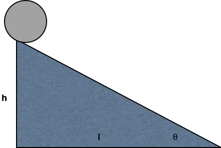

## Psychology is harder than physics

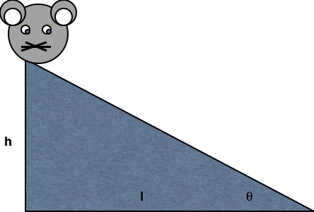

## Behavior has multiple, nested dimensions

[video not shown]

Adolph, K., Tamis-LeMonda, C. & Gilmore, R.O. (2016). PLAY Project: Webinar discussions on protocol and coding. Databrary. Retrieved February 17, 2017 from https://nyu.databrary.org/volume/232

## Outline

- We've got problems…
- Small-scale solutions…
- Bigger, I mean HYUUGE, solutions

## Problems facing behavioral science

## Fraud

- [Michael LaCour](http://www.nature.com/news/political-science-s-problem-with-research-ethics-1.17866)
  - Broockman, D., Kalla, J., Aronow, P. (2015, May 19). Irregularities in LaCour (2014). Retrieved February 16, 2017 from http://stanford.edu/~dbroock/broockman_kalla_aronow_lg_irregularities.pdf
- [Diederik Stapel](http://www.nytimes.com/2013/04/28/magazine/diederik-stapels-audacious-academic-fraud.html?pagewanted=all&_r=0)
  - [Commentary](http://root.bryancavemedia.com/marketing/downloads/schooled_in_fraud_compliance_lessons_from_lying_dutchman_killingsworth.pdf)

## Michael LaCour

[figure not shown]

## Diederik Stapel

- Dean of the School of Social and Behavioral Sciences at Tilburg University
- Teacher of Scientific Ethics course
- Fraud investigation launched when 3 grad students noticed anomalies – duplicate entries in data tables
- Stapel confessed, lost position, gave up Ph.D., wrote a book
- Details in [Flawed science: The fraudulent research practices of social psychologist Diederik Stapel](http://pubman.mpdl.mpg.de/pubman/item/escidoc:1569964:8/component/escidoc:1569966/Stapel_Investigation_Final_report.pdf)

## Self-reported data fabrication, falsification, and alteration

[figure not shown]

[(Fanelli 2009)](https://doi.org/10.1371/journal.pone.0005738)

## Self-reports of questionable research practices

[figure not shown]

[(Fanelli 2009)](https://doi.org/10.1371/journal.pone.0005738)

[(Fanelli 2009)](https://doi.org/10.1371/journal.pone.0005738)

## Misconduct

- [Marc Hauser](http://www.sciencemag.org/news/2012/09/harvard-psychology-researcher-committed-fraud-us-investigation-concludes)
  - http://www.sciencemag.org/news/2014/05/harvard-misconduct-investigation-psychologist-released

## Marc Hauser

- Evolutionary/Comparative Psychologist, Professor at Harvard
- Resigned 2011 after internal investigation found him responsible for research misconduct
- Details see [2012 report by NIH Office of Research Integrity (ORI)](https://grants.nih.gov/grants/guide/notice-files/NOT-OD-12-149.html) and [Hauser's response](http://archive.boston.com/whitecoatnotes/2012/09/05/marc-hauser-responds-federal-finding-scientific-misconduct/spzRWEVIPKA4BUu8wi8t8J/story.html).

## Mistakes, e.g., flexible "stopping" rules

[figure not shown]

[(Simmons, Nelson, and Simonsohn 2011)](http://doi.org/10.1177/0956797611417632)

## Errors/omissions in data

- C. Reinhart and K. Rogoff paper, http://www.nber.org/papers/w15639.pdf?new_window=1
  - Omitted data in Excel spreadsheet used to model effect of public debt on econcomic growth. https://www.bloomberg.com/news/articles/2013-04-18/faq-reinhart-rogoff-and-the-excel-error-that-changed-history
  - Error only found when data were shared.

## Reproducibility "Crisis"

- [Reproducibility Project: Psychology](https://osf.io/ezcuj/)
- Attempt to replicate 100 experimental and correlational studies published in three psychology journals in 2008 using high-powered designs and original materials when available.
- Materials, data, protocols, analysis code shared via the [Open Science Framework (OSF)](http://osf.io) from the [Center for Open Science (COS)](http://cos.io)

## Results published in [(Collaboration 2015)](http://doi.org/10.1126/science.aac4716)

- 39/98 (39.7%) replication attempts were successful
- 97% of original studies reported statistically significant results vs. 36% of replications

[figure not shown]

[(Collaboration 2015)](http://doi.org/10.1126/science.aac4716)

## So, did the studies replicate? [(Gilbert et al. 2016)](http://doi.org/10.1126/science.aad7243)

- Samples not equal
  - Sampling error differences predicts < 100% reproducibility

## So, did the studies replicate? [(Gilbert et al. 2016)](http://doi.org/10.1126/science.aad7243)

- Protocols not identical
  - Only 69% of original PIs "endorsed" replication protocol. Replication rate 4x higher (59.7% vs. 15.4%) in studies with endorsed protocol.
  - What is CI of *expected* effect sizes given sample/methodological variability? [Many Labs project](https://osf.io/wx7ck/wiki/home/)

[figure not shown]

[Many Labs project](https://osf.io/wx7ck/wiki/home/)

## So, did the studies replicate? [(Gilbert et al. 2016)](http://doi.org/10.1126/science.aad7243)

[(Collaboration 2015)](http://doi.org/10.1126/science.aac4716) *"…seriously underestimated reproducibility of psychological science."*

## Not just social & behavioral science

- [Reproducibility initiative in cancer biology](http://blogs.nature.com/news/2013/10/initiative-gets-1-3-million-to-verify-findings-of-50-high-profile-cancer-papers.html).
  - [Details on OSF](https://osf.io/e81xl/)
- Significant concerns about reproducibility of biomedical science findings have been raised: [(Begley and Ellis 2012)](http://doi.org/10.1038/483531a) and [(Prinz, Schlange, and Asadullah 2011)](http://doi.org/10.1038/nrd3439-c1)

## Is there a reproducibility crisis?

- Yes, a significant crisis.
- Yes, a slight crisis.
- No, there is no crisis.
- Don't know.

## Is there a reproducibility crisis?

- Yes, a significant crisis.
- Yes, a slight crisis.
- No, there is no crisis.
- Don't know.

## Is there a reproducibility crisis?

- Yes, a significant crisis.
- Yes, a slight crisis.
- No, there is no crisis.
- Don't know.

## Is there a reproducibility crisis?

- Yes, a significant crisis.
- Yes, a slight crisis.
- No, there is no crisis.
- Don't know.

## Is there a reproducibility crisis?

- Yes, a significant crisis.
- Yes, a slight crisis.
- No, there is no crisis.
- Don't know.

## Is there a reproducibility crisis?

[figure not shown]

[(Baker 2016)](http://doi.org/10.1038/533452a)

[figure not shown]

[(Baker 2016)](http://doi.org/10.1038/533452a)

[figure not shown]

[(Baker 2016)](http://doi.org/10.1038/533452a)

## Lack of clarity/agreement about reproducibility

- What does it mean to evaluate reproducibility across a field or subfield?
- Are we clear about what 'reproducibility' means? [(Goodman, Fanelli, and Ioannidis 2016)](http://doi.org/10.1126/scitranslmed.aaf5027)
- **Methods** reproducibility refers to *"…the ability to implement, as exactly as possible, the experimental and computational procedures, with the same data and tools, to obtain the same results."*
- **Results** reproducibility *"(previously described as replicability) refers to obtaining the same results from the conduct of an independent study whose procedures are as closely matched to the original experiment as possible."*
- **Inferential** reproducibility *"…refers to the drawing of qualitatively similar conclusions from either an independent replication of a study or a reanalysis of the original study"*

[(Goodman, Fanelli, and Ioannidis 2016)](http://doi.org/10.1126/scitranslmed.aaf5027)

## Sampling challenges

- Much (lab-based) data collected are from **W**estern, **E**ducated **I**ndustrialized, **R**ich, **D**emocratic (WEIRD) populations [(Henrich, Heine, and Norenzayan 2010)](http://doi.org/10.1017/S0140525X0999152X)
- Even on [Mechanical Turk](http://www.behind-the-enemy-lines.com/2015/04/demographics-of-mechanical-turk-now.html)

[figure not shown]

See also: http://demographics.mturk-tracker.com/

## Studies are underpowered

- Maxwell, S. E. (2004). The Persistence of Underpowered Studies in Psychological Research: Causes, Consequences, and Remedies. *Psychological Methods*, 9(2), 147–163. https://doi.org/10.1037/1082-989X.9.2.147
- Ioannidis, J. P. A. (2005). Why Most Published Research Findings Are False. *PLOS Medicine*, 2(8), e124. https://doi.org/10.1371/journal.pmed.0020124

## [(Szucs and Ioannidis 2016)](http://doi.org/10.1101/071530)

"We have empirically assessed the distribution of published effect sizes and estimated power by extracting more than 100,000 statistical records from about 10,000 cognitive neuroscience and psychology papers published during the past 5 years. The reported median effect size was d=0.93 (inter-quartile range: 0.64-1.46) for nominally statistically significant results and d=0.24 (0.11-0.42) for non-significant results. Median power to detect small, medium and large effects was 0.12, 0.44 and 0.73, reflecting no improvement through the past half-century. Power was lowest for cognitive neuroscience journals. 14% of papers reported some statistically significant results, although the respective F statistic and degrees of freedom proved that these were non-significant; p value errors positively correlated with journal impact factors. False report probability is likely to exceed 50% for the whole literature. In light of our findings the recently reported low replication success in psychology is realistic and worse performance may be expected for cognitive neuroscience."

## Rich man…

- New data sources
  - Wearables
  - Electronic education records
  - Electronic medical records
  - Social media

[figure not shown]

## Poor man

[figure not shown]

## Limited data, materials sharing

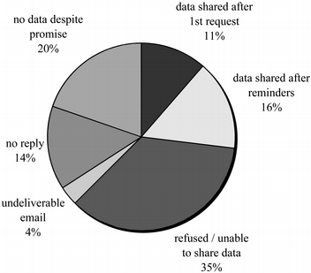

Wicherts, J. M., Borsboom, D., Kats, J., & Molenaar, D. (2006). The poor availability of psychological research data for reanalysis. American Psychologist, 61(7), 726–728. https://doi.org/10.1037/0003-066X.61.7.726

## Little improvement over time…

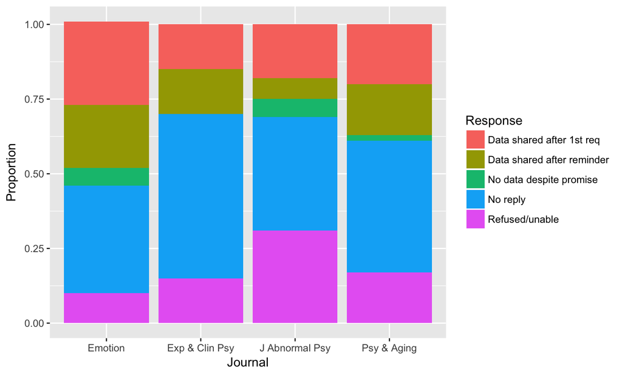

[(Vanpaemel et al. 2015)](http://doi.org/10.1525/collabra.13)

*American Psychologist*, *70*(6), Sept 2015

## What's at stake?

- A great deal
- Validity of our evidence
- Credibility of our arguments

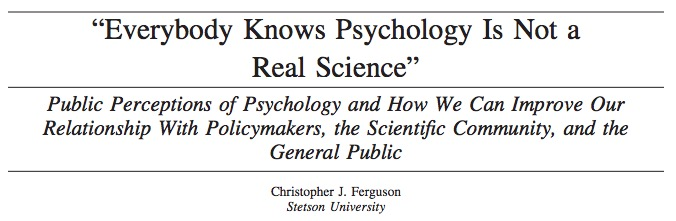

[(Ferguson 2015)](http://doi.org/10.1037/a0039405)

[figure not shown]

## In our defense…

- Science is hard
- Life is short
- Funding is competitive
- Incentive structure undermines transparency, openness, sharing

[figure not shown]

[(Higginson and Munafò 2016)](http://10.1371/journal.pbio.2000995)

## Psychology is harder than physics

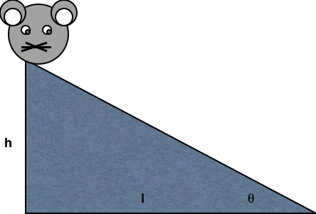

## Small-scale solutions

[figure not shown]

[(Baker 2016)](http://doi.org/10.1038/533452a)

## Change journal, funder practices

- [Transparency and opennness promotion (TOP) guidelines](https://osf.io/9f6gx/)
- [(B. A. Nosek et al. 2015)](http://doi.org/10.1126/science.aab2374)
- Citation
- Data transparency
- Analytic methods (code) transparency
- Design and analysis transparency
- Preregistration of studies
- Preregistration of analysis plans
- Replication

## Who's signed on and who hasn't?

- [List of TOP signatories](https://cos.io/top/#list)
- Declines
  - [(Lash 2015)](http://journals.lww.com/epidem/Fulltext/2015/11000/Declining_the_Transparency_and_Openness_Promotion.1.aspx)
  - Implementation would run counter to efforts to *"…maintain an editorial policy that encourages creativity and novelty, resists regimentation of research practices to the extent practicable, and invites challenges to current scientific habits and conventions through innovation in epidemiologic theory and practice."*

## On the other hand…

- New editorial from European Journal of Personality
  - https://twitter.com/i/web/status/818460818102697985

## [(Munafò et al. 2017)](http://doi.org/10.1038/s41562-016-0021) manifesto

[figure not shown]

## Improve methodology training

- [Literate Programming](http://www.literateprogramming.com/)
  - [RStudio](http://rstudio.com) and [R Markdown](http://rmarkdown.rstudio.com/)
  - [Jupyter](http://jupyter.org) notebooks
  - Electronic lab notebooks, talks, reports, articles…
- [Software Carpentry](https://software-carpentry.org/)
- Version control (e.g., GitHub)

## Data (materials and code) should be

- **F**indable, **A**ccessible, **I**nteroperable, and **R**euseable ([FAIR Data Principles](https://www.force11.org/group/fairgroup/fairprinciples)).
- [Published](https://en.wikipedia.org/wiki/Data_publishing#Paper) alongside articles or in data journals, e.g. [Nature Scientific Data](http://www.nature.com/sdata/).
  - Full disclosure: Gilmore on editorial board

## Data (materials and code) should be

- Stored in data repositories
  - [Open Science Framework (OSF)](https://osf.io/)
  - [Inter-university Consortium for Political and Social Research (ICPSR)](http://www.icpsr.umich.edu)
  - [Dataverse](http://dataverse.org)
  - [Dryad Data Repository](http://datadryad.org)
  - [Databrary](http://databrary.org)

[interactive chart not shown]

## [Databrary.org](http://databrary.org)

- Specializes in storing, sharing video
- Video captures behavior unlike other methods, but is *identifiable*
- Policy framework for sharing identifiable data
  - **Permission to share** -> builds on informed consent
  - **Restricted access** for (institutionally) authorized researchers

## Video essential for reproducibility

> *Amidst the recent flood of concerns about transparency and reproducibility in the behavioral and clinical sciences, we suggest a simple, inexpensive, easy-to-implement, and uniquely powerful tool to improve the reproducibility of scientific research and accelerate progress— video recordings of experimental procedures. Widespread use of video for documenting procedures could make moot disagreements about whether empirical replications truly reproduced the original experimental conditions. We call on researchers, funders, and journals to make commonplace the collection and open sharing of video-recorded procedures.*

[(Gilmore and Adolph 2017)](http://osf.io/3kvp7)

## [Clark, T.D. (2017, February 7). Science, lies, and video-taped experiments. *Nature*, *542*(7640).](http://www.nature.com/news/science-lies-and-video-taped-experiments-1.21432)

*If extreme athletes can use self-mounted cameras to record their wildest adventures during mountaintop blizzards, scientists have little excuse not to record what goes on in lab and field studies."*

## REALLY BIG solutions

## Thinking big…

[figure not shown]

## Imagine a 'Databservatory' for human behavior

[figure not shown]

## Imagine a Human Behaviorome

[figure not shown]

Shonkoff, J. P., & Phillips, D. A. (Eds.). (2000). From neurons to neighborhoods: The science of early childhood development. National Academies Press.

[figure not shown]

## What would this micro/macro/telescope look like?

- Recruiting – larger, more diverse samples
- Data collection – more data types, allow linkage across levels
- Data curation/management – easy/automatic, standardized formats
- Data sharing – PI controls when, permission levels
- Data mining, visualization, linking
- Search, filter by participant characteristics, tasks/measures, geo/temporal factors
- Analysis in the "cloud"
- Automatic versioning, history

[figure not shown]

## The front end

- App/web service
- Linking researchers with participants (and parents)
- Participants own/control their data, determine level of sharing (like [datawallet.io](https://datawallet.io/))
- Lab, computer/smart-phone based, survey tasks
- Data visualizations, dashboard – data as entertainment
- ~1,000+ psych pool/semester, 500K PSU alumni, 1M friends

[figure not shown]

## The middle

[figure not shown]

## Analytic/visualization engine

[figure not shown]

[video not shown]

[www.socialexplorer.com](http://www.socialexplorer.com/)

[video not shown]

wordbank.stanford.edu

[video not shown]

[(Tamis-LeMonda 2013)](http://doi.org/10.17910/B7CC74)

[video not shown]

neurosynth.org

## Problems to solved

## Data harmonization and preparation

- Astro, geo, bio-sciences have common frames of reference, linking variables

## Data harmonization and preparation

- Astro, geo, bio-sciences have common frames of reference, linking variables
- Essential data linkages in social/behavioral science
  - **People**
    - Age, sex/gender, race/ethnicity, …
  - **Locations**
    - Lat/Lon or Census Block Group/Tract
  - **Dates and times**
  - **Tasks/behaviors**

## Respecting privacy

- Asking participants **EXPLICIT** permission to share **with researchers** for **research** and educational purposes

[figure not shown]

## When asked, most participants say yes

[figure not shown]

Tamis-LeMonda, C. (2013). http://doi.org/10.17910/B7CC74.

[figure not shown]

http://www.humanconnectome.org/

[figure not shown]

## Respecting privacy

- Give participants meaningful ownership over their data
- Give participants value for contributing

## Clarifying the value of participating in research

- 'Free' service (email, calendar, search, communications platform) vs.
- Contributions to public good
- Aid discovery
- Feed curiosity
- Help institution, community, society

## Summing up

- Let's make behavioral science a model for transparency, innovation, and discovery
- **MeeSearch + Databservatory**
- Recruiting + data collection + harmonization + mining + sharing + open publication
- Shall we build it?
- Here and now?

[figure not shown]

## After all…

[figure not shown]

## References

Baker, Monya. 2016. “1,500 Scientists Lift the Lid on Reproducibility.” *Nature News* 533 (7604): 452. doi:10.1038/533452a.

Begley, C. Glenn, and Lee M. Ellis. 2012. “Drug Development: Raise Standards for Preclinical Cancer Research.” *Nature* 483 (7391): 531–33. doi:10.1038/483531a.

Collaboration, Open Science. 2015. “Estimating the Reproducibility of Psychological.” *Science* 349 (6251): aac4716. doi:10.1126/science.aac4716.

Fanelli, Daniele. 2009. “How Many Scientists Fabricate and Falsify Research? A Systematic Review and Meta-Analysis of Survey Data.” *PLOS ONE* 4 (5): e5738. doi:10.1371/journal.pone.0005738.

Ferguson, Christopher J. 2015. “‘Everybody Knows Psychology Is Not a Real Science’: Public Perceptions of Psychology and How We Can Improve Our Relationship with Policymakers, the Scientific Community, and the General Public.” *American Psychologist* 70 (6): 527–42. doi:10.1037/a0039405.

Gilbert, Daniel T., Gary King, Stephen Pettigrew, and Timothy D. Wilson. 2016. “Comment on ‘Estimating the Reproducibility of Psychological Science’.” *Science* 351 (6277): 1037–7. doi:10.1126/science.aad7243.

Gilmore, R.O., and K.E. Adolph. 2017. “Video Can Make Science More Open, Transparent, Robust, and Reproducible,” February. http://osf.io/3kvp7.

Goodman, Steven N., Daniele Fanelli, and John P. A. Ioannidis. 2016. “What Does Research Reproducibility Mean?” *Science Translational Medicine* 8 (341): 341ps12–341ps12. doi:10.1126/scitranslmed.aaf5027.

Henrich, Joseph, Steven J. Heine, and Ara Norenzayan. 2010. “The Weirdest People in the World?” *The Behavioral and Brain Sciences* 33 (2-3): 61–83; discussion 83–135. doi:10.1017/S0140525X0999152X.

Higginson, Andrew D., and Marcus R. Munafò. 2016. “Current Incentives for Scientists Lead to Underpowered Studies with Erroneous Conclusions.” *PLOS Biology* 14 (11): e2000995. doi:10.1371/journal.pbio.2000995.

Lash, Timothy L. 2015. “Declining the Transparency and Openness Promotion Guidelines.” *Epidemiology* 26 (6). LWW: 779–80. http://journals.lww.com/epidem/Fulltext/2015/11000/Declining_the_Transparency_and_Openness_Promotion.1.aspx.

Munafò, Marcus R., Brian A. Nosek, Dorothy V. M. Bishop, Katherine S. Button, Christopher D. Chambers, Nathalie Percie du Sert, Uri Simonsohn, Eric-Jan Wagenmakers, Jennifer J. Ware, and John P. A. Ioannidis. 2017. “A Manifesto for Reproducible Science.” *Nature Human Behaviour* 1 (January): 0021. doi:10.1038/s41562-016-0021.

Nosek, B. A., G. Alter, G. C. Banks, D. Borsboom, S. D. Bowman, S. J. Breckler, S. Buck, et al. 2015. “Promoting an Open Research Culture.” *Science* 348 (6242): 1422–5. doi:10.1126/science.aab2374.

Prinz, Florian, Thomas Schlange, and Khusru Asadullah. 2011. “Believe It or Not: How Much Can We Rely on Published Data on Potential Drug Targets?” *Nature Reviews Drug Discovery* 10 (9): 712–12. doi:10.1038/nrd3439-c1.

Simmons, Joseph P., Leif D. Nelson, and Uri Simonsohn. 2011. “False-Positive Psychology: Undisclosed Flexibility in Data Collection and Analysis Allows Presenting Anything as Significant.” *Psychological Science* 22 (11): 1359–66. doi:10.1177/0956797611417632.

Szucs, Denes, and John PA Ioannidis. 2016. “Empirical Assessment of Published Effect Sizes and Power in the Recent Cognitive Neuroscience and Psychology Literature.” *BioRxiv*, August, 071530. doi:10.1101/071530.

Tamis-LeMonda, Catherine. 2013. “Language, Cognitive, and Socio-Emotional Skills from 9 Months Until Their Transition to First Grade in U.S. Children from African-American, Dominican, Mexican, and Chinese Backgrounds.” Databrary. doi:10.17910/B7CC74.

Vanpaemel, Wolf, Maarten Vermorgen, Leen Deriemaecker, and Gert Storms. 2015. “Are We Wasting a Good Crisis? The Availability of Psychological Research Data After the Storm.” *Collabra: Psychology* 1 (1). doi:10.1525/collabra.13.